# Analysis of in vivo Isotope Labeled Duckweed

### 4.1 Lipid Analysis

We create a subset for the desired mass range and re-normalize. Below, the mean mass spectrum for just the mass range 800-1200.

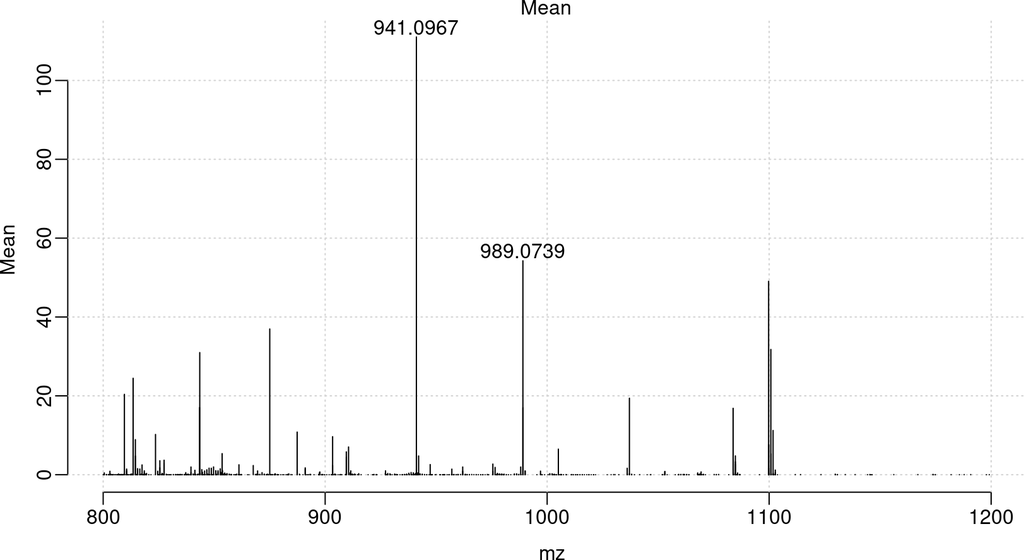

```r
fiveB_lipids <- subsetFeatures(fiveB_normAlign,800 < mz, mz < 1200)
fiveB_lipids <- normalize(fiveB_lipids, method="tic")|>
  process()

fiveB_lipids <- fiveB_lipids |>
  summarizePixels(c(TIC="sum")) |>
  summarizeFeatures(c(Mean = "mean"))

plot(fiveB_lipids, "Mean", annPeaks = 2)
```

We, again, use SSC segmentation to find the tissue region and separate it from the background.

```r
fiveB_lipids_ssc <- spatialShrunkenCentroids(fiveB_lipids, r = 2,
                                                s = 0, k = 2)
fiveB_lipids_ssc
fiveB_lipids$regions <- makeFactor(tissue = (fiveB_lipids_ssc@model[["class"]]!=1),
                                  bkgd = (fiveB_lipids_ssc@model[["class"]]==1))
```

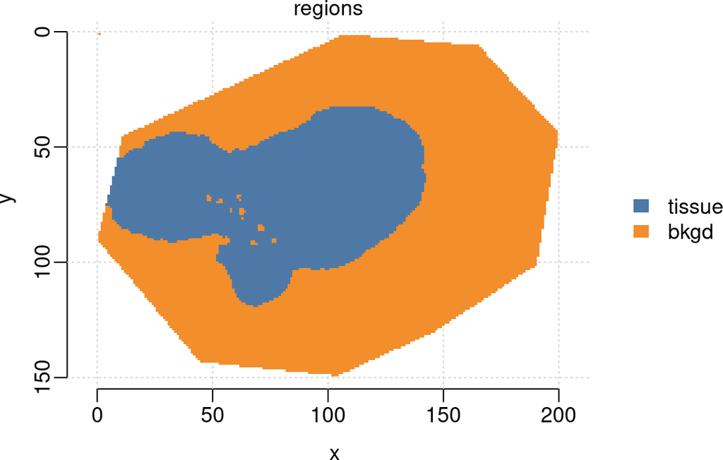

```r
image(fiveB_lipids,"regions")
```

Below, we plot the mean mass spectrum of the tape background for m/z 800-1200.

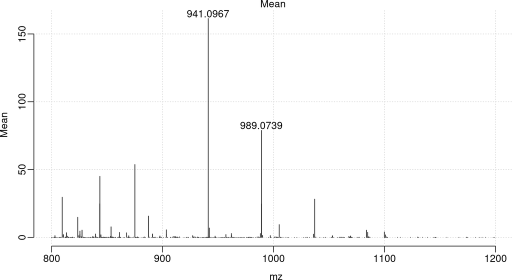

```r
fiveB_bkgd_lipids <- subsetPixels(fiveB_lipids, regions == "bkgd")
fiveB_bkgd_lipids <- fiveB_bkgd_lipids |>
  summarizePixels(c(TIC="sum")) |>
  summarizeFeatures(c(Mean = "mean"))
plot(fiveB_bkgd_lipids, "Mean", annPeaks = 2)
```

We perform SSC segmentation on the tissue-only pixels and plot the t-statistics showing the differences between the two regions.

```r
fiveB_tissue_lipids <- subsetPixels(fiveB_lipids, regions == "tissue")
fiveB_tissue_lipids_ssc <- spatialShrunkenCentroids(fiveB_tissue_lipids, r=3,
                                            k = 2, s=8,
                                            weights="gaussian")
```

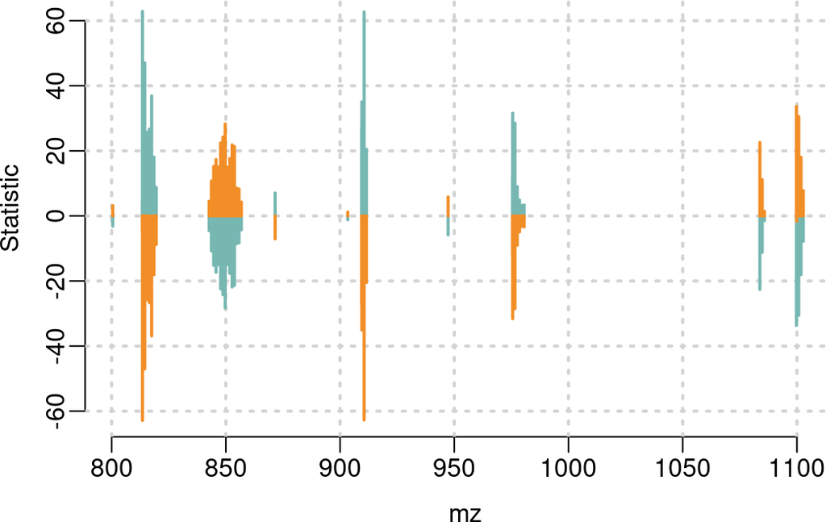

```r
fiveB_lipid_top <- topFeatures(fiveB_tissue_lipids_ssc)
plot(fiveB_tissue_lipids_ssc, type="statistic",lwd = 2,
     col=c("#76B7B2","#F28E27"), key = FALSE)
```

We also show the differences in shrunken centroids.

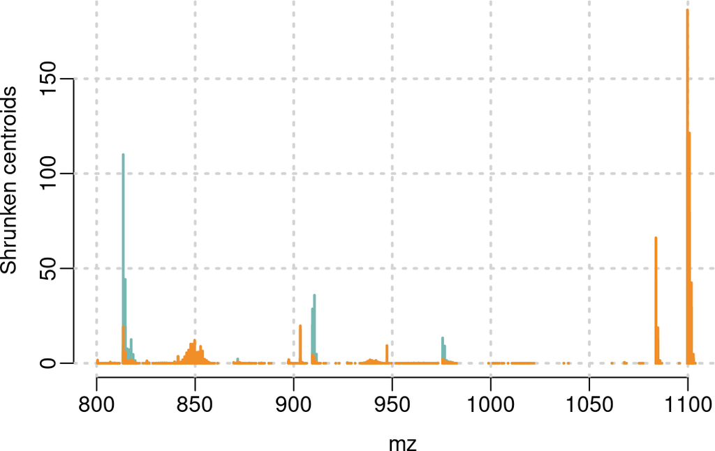

```r
plot(fiveB_tissue_lipids_ssc, type="centers",lwd = 2,
     col=c("#76B7B2","#F28E27"), key =FALSE)
```

Finally, we annotate the two regions as parent and daughter.

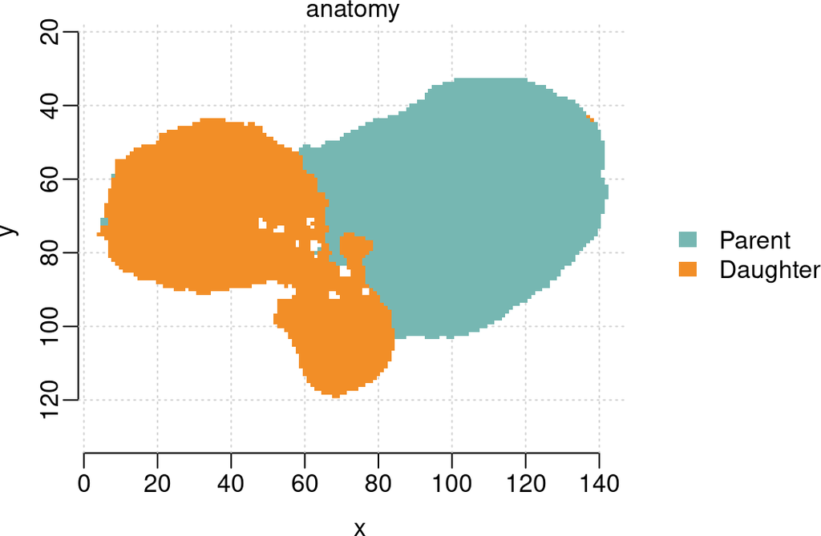

```r
fiveB_tissue_lipids$anatomy <- makeFactor(
  Parent = (fiveB_tissue_lipids_ssc@model[["class"]] == 1),
  Daughter = (fiveB_tissue_lipids_ssc@model[["class"]] == 2))
image(fiveB_tissue_lipids, "anatomy", col=c("#76B7B2","#F28E27"))
```

### 4.2 Whole Mass Range Analysis

We use the intital segmentation from the higher mass range to select the tissue and background regions of the entire mass range. Below, the mean mass spectrum for the background.

```r
fiveB_normAlign$regions <- makeFactor(tissue = (fiveB_lipids_ssc@model[["class"]]!=1),
                                  bkgd = (fiveB_lipids_ssc@model[["class"]]==1))
fiveB_tissue <- subsetPixels(fiveB_normAlign, regions == "tissue")
fiveB_bkgd <- subsetPixels(fiveB_normAlign, regions == "bkgd")

fiveB_bkgd <- fiveB_bkgd |>
  summarizePixels(c(TIC="sum")) |>
  summarizeFeatures(c(Mean = "mean"))
```

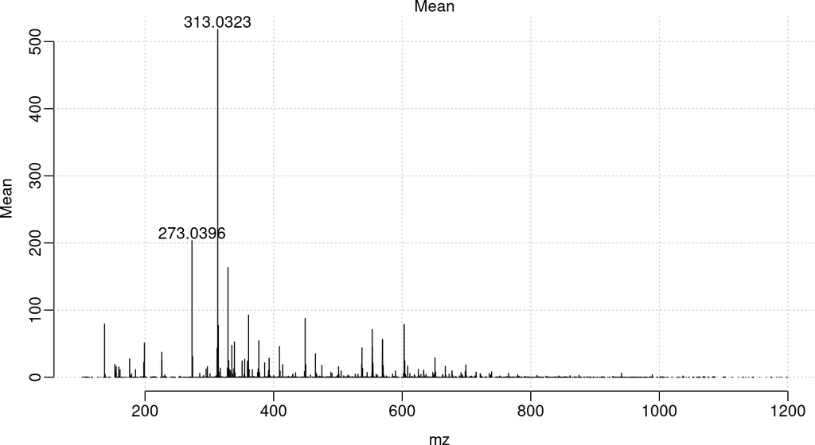

```r
plot(fiveB_bkgd, "Mean", annPeaks = 2)
```

Here, we plot the mean mass spectrum of the tissue region. Unlike the 13-carbon labeled samples, the isotope labeling is much harder to distinguish from the high intensity chemical noise peaks.

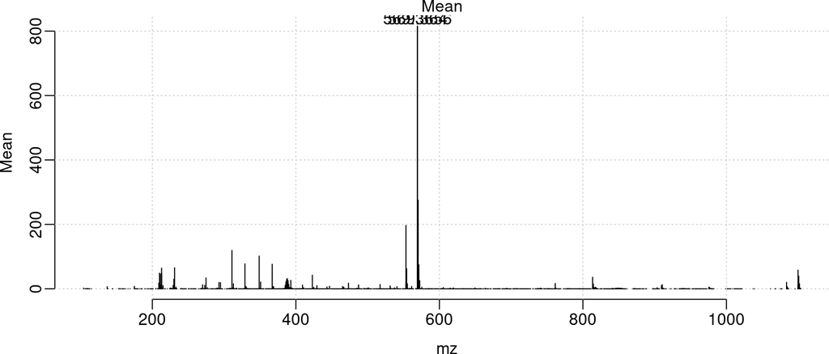

```r
fiveB_tissue <- fiveB_tissue |>
  summarizePixels(c(TIC="sum")) |>
  summarizeFeatures(c(Mean = "mean"))
plot(fiveB_tissue, "Mean", annPeaks = 2)
```

We perform SSC segmentation on the tissue region of the dataset and show the results of all six models.

```r
fiveB_tissue_ssc <- spatialShrunkenCentroids(fiveB_tissue, r=3, k=5, s=2^(0:5),
                                             weights="adaptive")
```

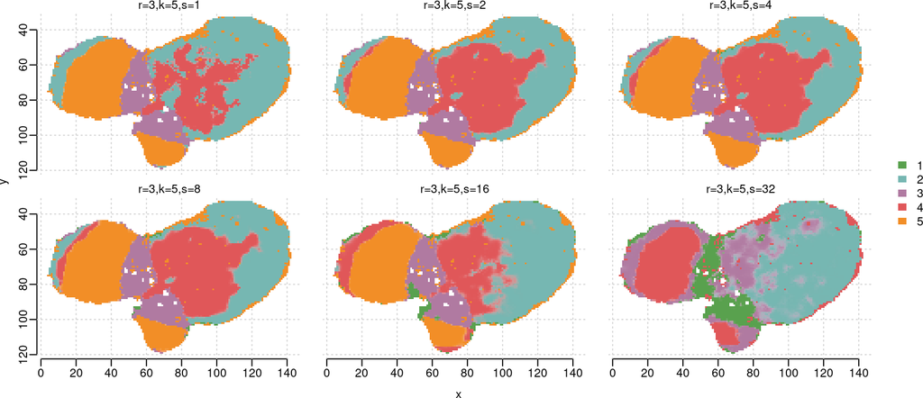

```r
image(fiveB_tissue_ssc, i = 1:6,
      col=c("#59A14E","#76B7B2","#B07AA1","#E05759","#F28E27"))
```

After selecting the model with s = 8 as an example, we plot the t-statistics.

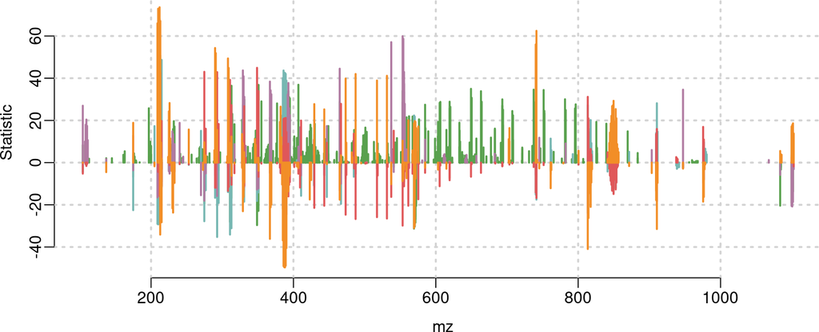

```r
fiveB_tissue_Mdl4 <- fiveB_tissue_ssc[[4]]
fiveB_tissue_top <- topFeatures(fiveB_tissue_Mdl4)

plot(fiveB_tissue_Mdl4, type="statistic", lwd = 2, key = FALSE,
     col=c("#59A14E","#76B7B2","#B07AA1","#E05759","#F28E27") )
```

We also provide the shrunken centroids.

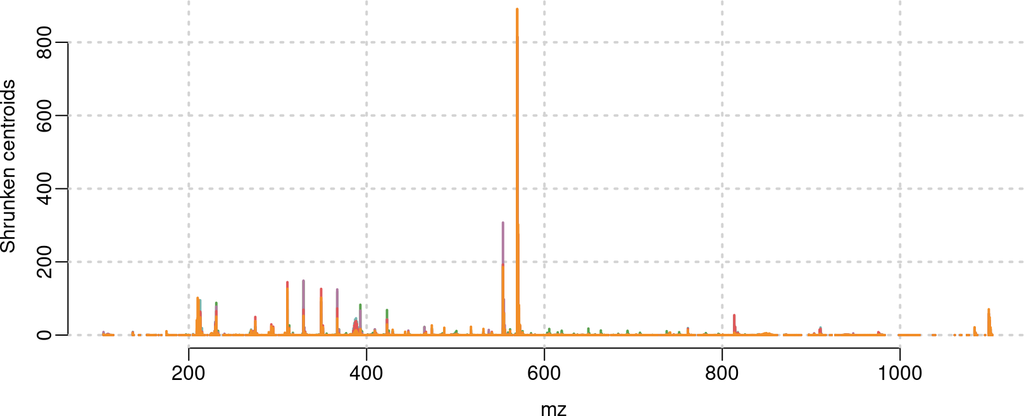

```r
plot(fiveB_tissue_Mdl4, type="centers", lwd = 2, key = FALSE,
     col=c("#59A14E","#76B7B2","#B07AA1","#E05759","#F28E27") )
```

Here, we annotate the five detected regions.

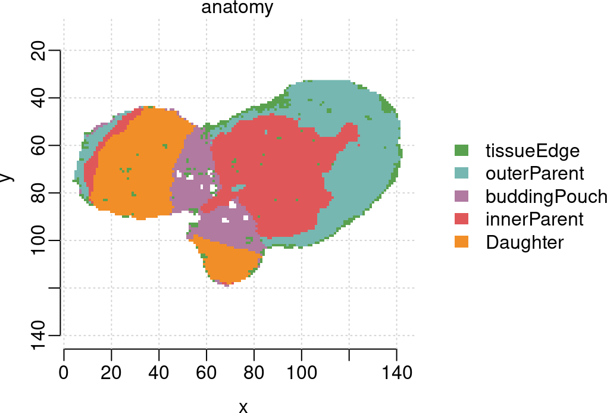

```r
fiveB_tissue$anatomy <- makeFactor(
  tissueEdge = (fiveB_tissue_Mdl4@model[["class"]] == 1),
  outerParent = (fiveB_tissue_Mdl4@model[["class"]] == 2),
  buddingPouch = (fiveB_tissue_Mdl4@model[["class"]] == 3),
  innerParent = (fiveB_tissue_Mdl4@model[["class"]] == 4),
  Daughter = (fiveB_tissue_Mdl4@model[["class"]] == 5))
image(fiveB_tissue, "anatomy",
      col=c("#59A14E","#76B7B2","#B07AA1","#E05759","#F28E27"))
```